# Computing hyperbolic magnitudes

Last successfully run: Apr 26, 2023

[Implementation](https://github.com/jlvdb/hyperbolic) of Lupton et al. (1999) by Jan Luca van den Busch.

Hyperbolic magnitudes aim to overcome limitations of classical magnitudes, which are logarithmic in flux. Hyperbolic magnitudues are implemented using the inverse hyperbolic sine and therefore have a linear behaviour in flux at low signal to noise, which gradually transitions to the classical logarithmic scaling at high signal to noise (i.e. equivalent to classical magnitudes in this limit).

This notebooks provides an example of how to convert classical to hyperbolical magnitudes using the pipeline stages `HyperbolicSmoothing` and `HyperbolicMagnitudes` in the `rail.core` module.

```python
import os

import numpy as np
import matplotlib.pyplot as plt

import rail
from rail.core.data import TableHandle
from rail.core.stage import RailStage
from rail.core.utilPhotometry import HyperbolicSmoothing, HyperbolicMagnitudes
```

We first set up a data store for interactive usage of RAIL (see the `examples/goldenspike_examples/goldenspike.ipynb` for further examples).

```python
DS = RailStage.data_store
DS.__class__.allow_overwrite = True
```

Next we load some DC2 sample data that provides LSST ugrizy magnitudes and magnitude errors, which we want to convert to hyperbolic magnitudes.

```python
from rail.core.utils import RAILDIR
testFile = os.path.join(RAILDIR, 'rail', 'examples_data', 'testdata', 'test_dc2_training_9816.pq')
test_mags = DS.read_file("test_data", TableHandle, testFile)
```

## Determining the smoothing parameters

First we run the `rail.core.HyperbolicSmoothing` stage. This stage computes the smoothing parameter (called $b$ in Lupton et al. 1999), which determines the transition between the linear and logarithmic behaviour of the hyperbolic magnitudes.

The **input** for this stage is a table containing magnitudes and magnitude errors per object (fluxes are also supported as input data by setting `is_flux=True` in the configuration). In this example, we assume that the magnitude zeropoint is 0.0 and that we want to convert all 6 LSST bands. This can be specified with the `value_columns` and `error_columns` parameters, which list the names of the magnitude columns and their corresponding magnitude errors.

```python
lsst_bands = 'ugrizy'
configuration = dict(
    value_columns=[f"mag_{band}_lsst" for band in lsst_bands],
    error_columns=[f"mag_err_{band}_lsst" for band in lsst_bands],
    zeropoints=[0.0] * len(lsst_bands),
    is_flux=False)

smooth = HyperbolicSmoothing.make_stage(name='hyperbolic_smoothing', **configuration)
smooth.compute(test_mags)
```

```
Inserting handle into data store.  parameters_hyperbolic_smoothing: inprogress_parameters_hyperbolic_smoothing.pq, hyperbolic_smoothing
```

```
<rail.core.data.PqHandle at 0x7f41dbfaf670>
```

The **output** of this stage is a table of relevant statistics required to compute the hyperbolic magnitudes per filter:

- the median flux error
- the zeropoint (which can be computed by comparing fluxes and magnitudes in the original `hyperbolic` code)
- the reference flux $f_{\rm ref}$ that corresponds to the given zeropoint
- the smoothing parameter $b$ (in terms of the absolute and the relative flux $x = f / f_{\rm ref}$

The `field ID` column is currently not used by the RAIL module and can be ignored.

```python
smooth_params = smooth.get_handle("parameters").data
smooth_params
```

| filter | field ID | flux error | zeropoint | ref. flux | b relative | b absolute |
| --- | --- | --- | --- | --- | --- | --- |
| mag_u_lsst | 0 | 1.559839e-11 | 0.0 | 1.0 | 1.625332e-11 | 1.625332e-11 |
| mag_g_lsst | 0 | 3.286980e-12 | 0.0 | 1.0 | 3.424989e-12 | 3.424989e-12 |
| mag_r_lsst | 0 | 3.052049e-12 | 0.0 | 1.0 | 3.180194e-12 | 3.180194e-12 |
| mag_i_lsst | 0 | 4.441195e-12 | 0.0 | 1.0 | 4.627666e-12 | 4.627666e-12 |
| mag_z_lsst | 0 | 7.823318e-12 | 0.0 | 1.0 | 8.151793e-12 | 8.151793e-12 |
| mag_y_lsst | 0 | 1.785106e-11 | 0.0 | 1.0 | 1.860057e-11 | 1.860057e-11 |

## Computing the magnitudes

Based on the smoothing parameters, the hyperbolic magnitudes are computed with be computed by `rail.core.HyperbolicMagnitudes`.

The **input** for this module is, again, the table with magnitudes and magnitude errors and the output table of `rail.core.HyperbolicSmoothing`.

```python
hypmag = HyperbolicMagnitudes.make_stage(name='hyperbolic_magnitudes', **configuration)
hypmag.compute(test_mags, smooth_params)
```

```
Inserting handle into data store.  parameters: None, hyperbolic_magnitudes
Inserting handle into data store.  output_hyperbolic_magnitudes: inprogress_output_hyperbolic_magnitudes.pq, hyperbolic_magnitudes
```

```
<rail.core.data.PqHandle at 0x7f41dbff7a90>
```

The **output** of this module is a table with hyperbolic magnitudes and their corresponding error.

**Note:** The current default is to relabel the columns names by substituting `mag_` by `mag_hyp_`. If this substitution is not possible, the column names are identical to the input table with classical magnitudes.

```python
test_hypmags = hypmag.get_handle("output").data
test_hypmags
```

|  | mag_hyp_u_lsst | mag_hyp_err_u_lsst | mag_hyp_g_lsst | mag_hyp_err_g_lsst | mag_hyp_r_lsst | mag_hyp_err_r_lsst | mag_hyp_i_lsst | mag_hyp_err_i_lsst | mag_hyp_z_lsst | mag_hyp_err_z_lsst | mag_hyp_y_lsst | mag_hyp_err_y_lsst |
| --- | --- | --- | --- | --- | --- | --- | --- | --- | --- | --- | --- | --- |
| 0 | 18.040370 | 0.005046 | 16.960892 | 0.005001 | 16.653413 | 0.005001 | 16.506310 | 0.005001 | 16.466378 | 0.005001 | 16.423906 | 0.005003 |
| 1 | 21.615533 | 0.009551 | 20.709402 | 0.005084 | 20.533851 | 0.005048 | 20.437566 | 0.005075 | 20.408885 | 0.005193 | 20.388203 | 0.005804 |
| 2 | 21.851866 | 0.011146 | 20.437067 | 0.005057 | 19.709715 | 0.005015 | 19.312630 | 0.005016 | 18.953412 | 0.005023 | 18.770441 | 0.005063 |
| 3 | 19.976499 | 0.005477 | 19.128676 | 0.005011 | 18.803485 | 0.005005 | 18.619996 | 0.005007 | 18.546590 | 0.005014 | 18.479452 | 0.005041 |
| 4 | 22.294717 | 0.015481 | 21.242782 | 0.005182 | 20.911803 | 0.005084 | 20.731707 | 0.005118 | 20.700288 | 0.005308 | 20.644994 | 0.006211 |
| ... | ... | ... | ... | ... | ... | ... | ... | ... | ... | ... | ... | ... |
| 10220 | 25.732646 | 0.301680 | 25.301790 | 0.047027 | 25.099622 | 0.036055 | 25.180361 | 0.055825 | 25.295404 | 0.108750 | 25.229366 | 0.226270 |
| 10221 | 25.251545 | 0.205102 | 24.512358 | 0.023323 | 24.345662 | 0.018623 | 24.434138 | 0.028559 | 24.547622 | 0.055349 | 24.678486 | 0.140864 |
| 10222 | 25.147493 | 0.187751 | 24.113802 | 0.016640 | 23.828346 | 0.012276 | 23.711119 | 0.015380 | 23.755514 | 0.027202 | 23.830545 | 0.065739 |
| 10223 | 26.305978 | 0.435503 | 25.067304 | 0.038089 | 24.770026 | 0.026890 | 24.586800 | 0.032711 | 24.781555 | 0.068406 | 24.653411 | 0.137773 |
| 10224 | 26.429216 | 0.461142 | 25.548904 | 0.058784 | 24.983338 | 0.032494 | 24.889564 | 0.042924 | 24.836702 | 0.071907 | 24.752944 | 0.150422 |

10225 rows × 12 columns

This plot shows the difference between the classical and hyperbolic magnitude as function of the classical $r$-band magnitude. The turn-off point is determined by the value for $b$ estimated above.

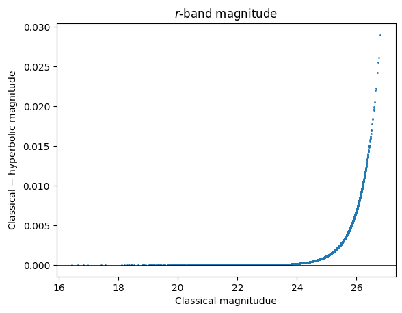

```python
filt = "r"

mag_class = test_mags.data[f"mag_{filt}_lsst"]
magerr_class = test_mags.data[f"mag_err_{filt}_lsst"]
mag_hyp = test_hypmags[f"mag_hyp_{filt}_lsst"]
magerr_hyp = test_hypmags[f"mag_hyp_err_{filt}_lsst"]

fig = plt.figure(dpi=100)
plt.axhline(y=0.0, color="k", lw=0.55)
plt.scatter(mag_class, mag_class - mag_hyp, s=1)
plt.xlabel("Classical magnitudue")
plt.ylabel("Classical $-$ hyperbolic magnitude")
plt.title("$r$-band magnitude")
```